# Лабораторная работа №1

Операционные системы

Чистов Д. М.

Российский университет дружбы народов, Москва, Россия

# Вступительная информация

## Цель работы

Целью данной работы является приобретение практических навыков установки операционной системы на виртуальную машину, настройки минимально необходимых для дальнейшей работы сервисов.

## Задание

1. Создание виртуальной машины
2. Установка Операционной Системы
3. После установки
4. Установка программного обеспечения
5. Дополнительные задания

# Выполнение лабораторной работы

## 1. Создание виртуальной машины

Открываю программу VirtualBox и нажимаю кнопку “Создать”.

[figure not shown]

Интерфейс VirtualBox

## 1. Создание виртуальной машины

В всплывающем окне задаю имя виртуальной машины, путь, где она будет находиться, а также ISO-образ операционной системы Fedora.

[figure not shown]

Конфигурация виртуальной машины

## 1. Создание виртуальной машины

Задаю кол-во выделенной оперативной памяти и ядер процессора хостовой машины для виртуальной машины.

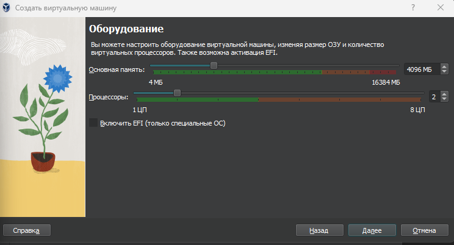

Конфигурация виртуальной машины 2

## 1. Создание виртуальной машины

Выделяю 80гб места своего жёсткого диска для виртуальной машины.

[figure not shown]

Конфигурация виртуальной машины 3

## 1. Создание виртуальной машины

На финальном экране проверяю корректность характеристик машины.

[figure not shown]

Конфигурация виртуальной машины 4

## 1. Создание виртуальной машины

Виртуальная машина успешно создана.

[figure not shown]

Просмотр виртуальной машины

## 2. Установка Операционной Системы

Запускаю виртуальную машину. Пока она будет запущена через образ ISO, который в будущем нужно будет отключить. Меня приветствует окно начала установки. Начинаем!

## 2. Установка Операционной Системы

Выбираю язык раскладки клавиатуры - русский и английский.

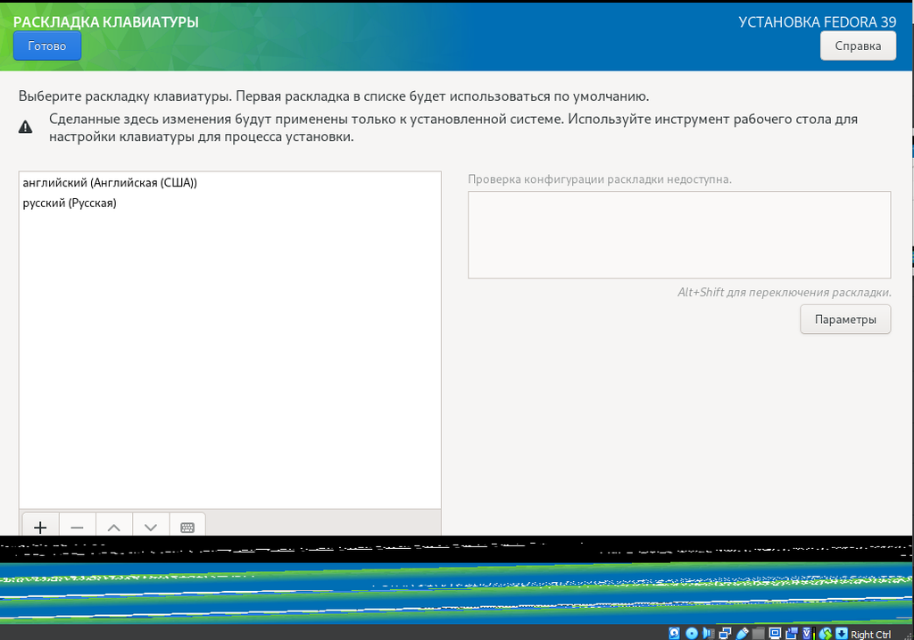

Раскладка клавиатуры

## 2. Установка Операционной Системы

Выбираю часовой пояс, который предоставит корректные для меня дату и время.

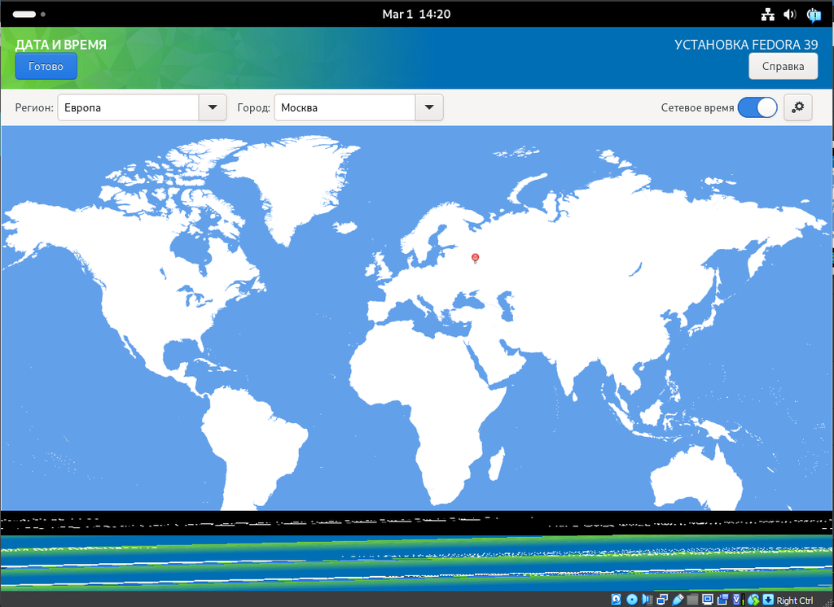

Дата и время

## 2. Установка Операционной Системы

Выбираю нужный жётский диск, на который будет установлена ОС.

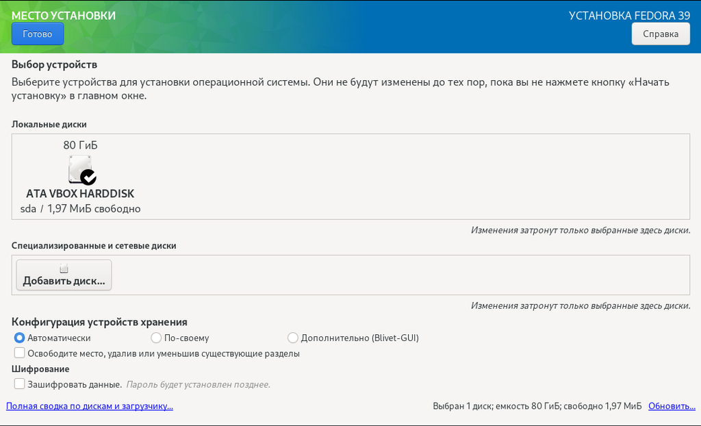

Жёсткий диск

## 2. Установка Операционной Системы

После всех конфигураций начинаю установку.

[figure not shown]

Установка ОС

## 2. Установка Операционной Системы

Установка прошла успешно.

[figure not shown]

Успешная установка ОС

## 2. Установка Операционной Системы

Теперь важный шаг. Открываю VirtualBox и ищу образ ISO.

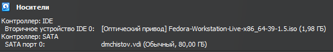

Образ ISO

## 2. Установка Операционной Системы

Нажимаю на него правой кнопкой мыши и отключаю от виртуальной машины.

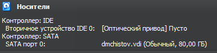

Отключённый образ ISO

## 2. Установка Операционной Системы

После этого перезапускаю виртуальную машину и наблюдаю, что ОС была установлена успешно.

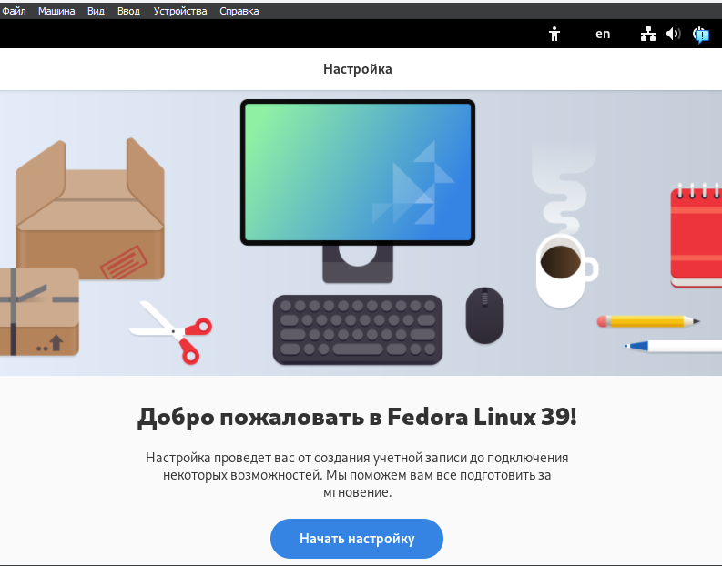

Успех в установке ОС

## 2. Установка Операционной Системы

Перехожу к настройке ОС. Создаю нового пользователя - ввожу своё имя и логин в соответствии с требованиями.

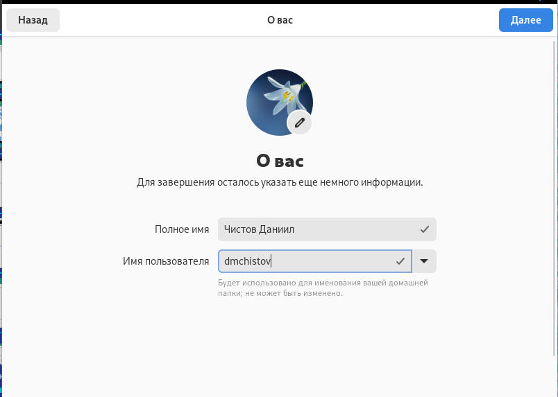

Новый пользователь

## 2. Установка Операционной Системы

Задаю пароль новому пользователю.

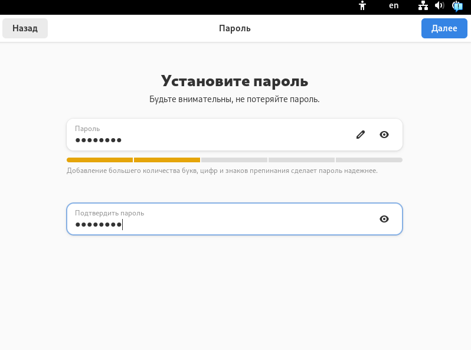

Пароль для пользователя

# 3. После установки

## Обновление пакетов

Открываю терминал, захожу в режим супер-пользователя и обновляю все пакеты.

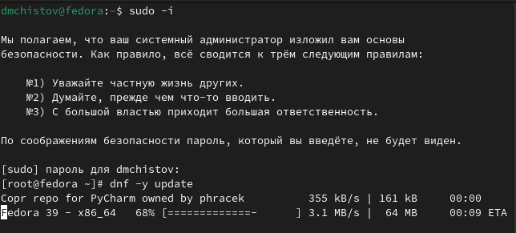

Обновление пакетов

## Повышение комфорта работы

Устанавливаю программу для удобства работы в консоли - tmux.

## Автоматическое обновление

Устанавливаю ПО для автоматического обновления.

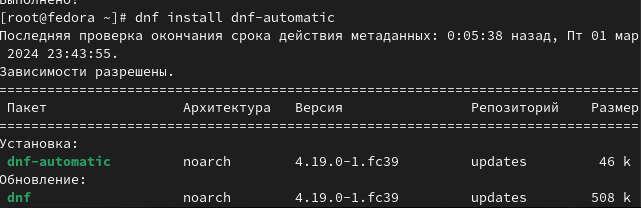

Установка ПО

## Автоматическое обновление

Устанавливаю таймер.

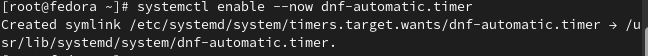

Установка таймера

## Отключение SELinux

По заданию требуют отключить SELinux, для начала нужно открыть Midnight Commander.

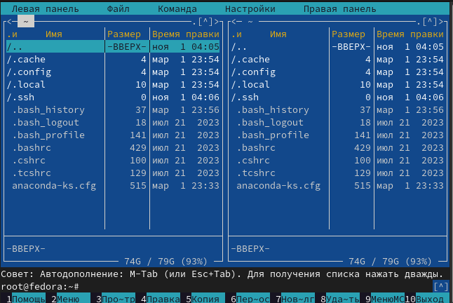

Midnight Commander

## Отключение SELinux

Перемещаюсь в папку /etc/selinux и нахожу файл config.

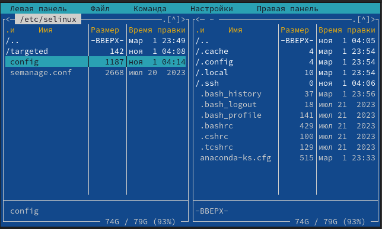

Найденный файл

## Отключение SELinux

Открываю его с помощью утилиты mcedit и заменяю параметр SELINUX с “enforcing” на “permissive”.

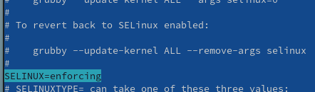

Файл config

## Отключение SELinux

После этого перезагружаю виртуальную машину.

## Устаовка драйверов VirtualBox

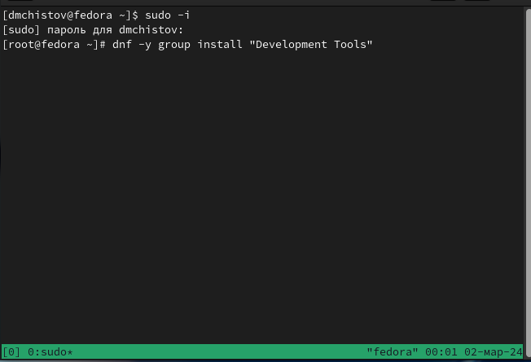

## Устаовка драйверов VirtualBox

После этого успешно устанавливаю пакет DKMS.

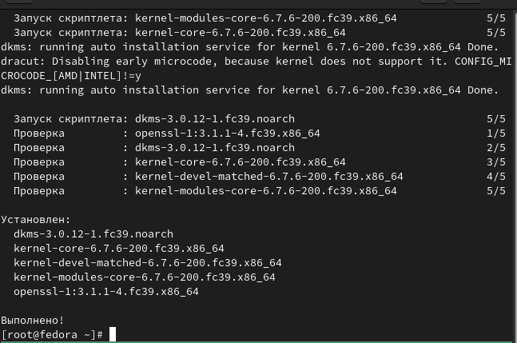

Установка DKMS

## Устаовка драйверов VirtualBox

Монтирую образ диска дополнений гостевой ОС, а затем подмонтирую его.

## Устаовка драйверов VirtualBox

Устанавливаю драйвера и перезагружаю виртульную машину.

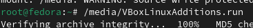

Установка драйверов

## Настройка раскладки клавиатуры

Открываю терминал, перехожу в роль супер-пользователя и редактирую файл /etc/X11/xorg.conf.d/00-keyboard.conf.

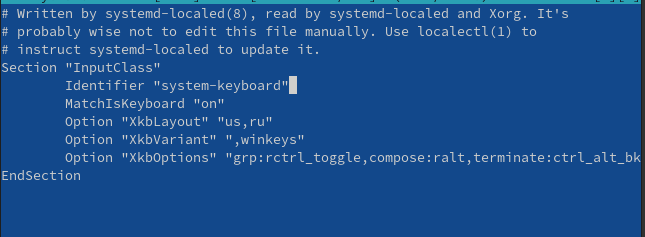

Редактирование файла

## Настройка раскладки клавиатуры

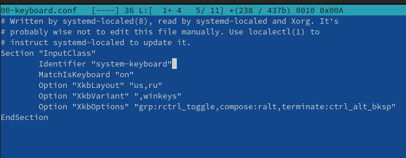

Отредактированный файл

## Настройка раскладки клавиатуры

Перезагружаю виртульную машину.

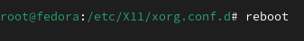

Перезагрузка

## Подключение общей папки

Внутри виртуальной машины добавляю своего пользователя в группу vboxsf.

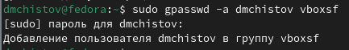

Пользователь в группе

## Подключение общей папки

Внутри своего компьюетра (ОС Windows 11), создаю общую папку в удобном месте, открываю консоль выбираю диск, на котором лежит общая папка, вспоминаю путь до общей папки и её название, их вписываю в особую комманду в консоли Windows.

[figure not shown]

Конфигурация внутри основного компьютера

## Подключение общей папки

Общая папка успешно установлена. Видно, что файл лежит внутри папки в Windows и такой же файл лежит в папке внутри виртуальной машины.

[figure not shown]

Файл в Windows

## Подключение общей папки

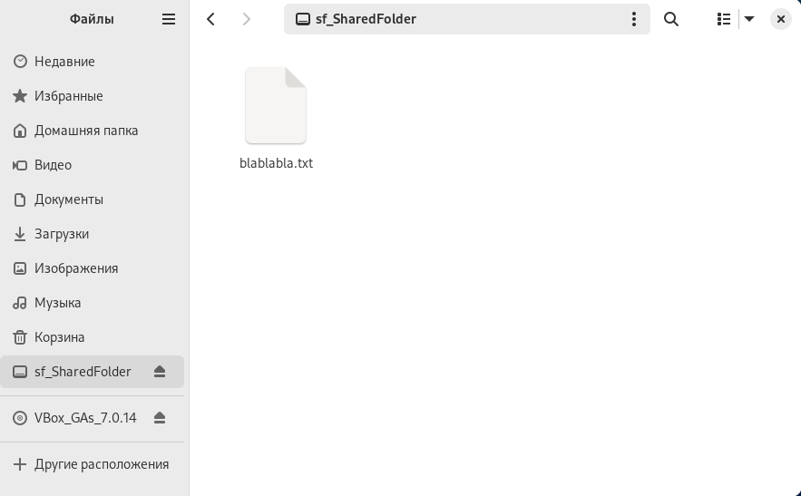

Файл внутри виртуальной машины